# Analyzing and predicting internet provider data

Damian Wisniewski

2023-08-09

In this project we will analyze the dataset in the file Churn.csv. Customer churn is a term used for when customers exit relationship with a company sercive. This data set contains information about properties of individuals who are using, or have stopped using,a service by an internet provider. In order to make decisions of potential measures to reduce churning we will predict two quantities: - The size of a subscriber bill - Probability that the customer churns

Data and structure

```r
churn <- read.csv('Churn.csv')

# Structure
str(churn)
```

```
## 'data.frame':    71893 obs. of  11 variables:
##  $ id                         : int  15 18 23 27 34 56 71 84 94 112 ...
##  $ is_tv_subscriber           : int  1 0 1 0 0 1 0 0 0 0 ...
##  $ is_movie_package_subscriber: int  0 0 0 0 0 1 0 0 0 0 ...
##  $ subscription_age           : num  11.95 8.22 8.91 6.87 6.39 ...
##  $ bill_avg                   : int  25 0 16 21 0 32 18 14 0 0 ...
##  $ remaining_contract         : num  0.14 0 0 0 0 1.38 0 0 0 0 ...
##  $ service_failure_count      : int  0 0 0 1 0 0 0 1 0 0 ...
##  $ download_avg               : num  8.4 0 13.7 0 0 69.4 21.3 0 0 0 ...
##  $ upload_avg                 : num  2.3 0 0.9 0 0 4 2 0 0 0 ...
##  $ download_over_limit        : int  0 0 0 0 0 0 0 0 0 0 ...
##  $ churn                      : int  0 1 1 1 1 0 1 1 1 1 ...
```

Change variables with few levels to factors. This makes sense because their numerical value is not meaningful for our analysis.

We take away variable ID since it does not benefit us in our analysis. We want to predict how likely it is that customers will churn in the future based on other data gathered, it is very unlikely that a specific customers ID can be associated with churning.

```r
# Change to factors variables with few levels
churn <- churn %>%
  mutate(
    is_tv_subscriber = as.factor(is_tv_subscriber),
    is_movie_package_subscriber = as.factor(is_movie_package_subscriber),
    churn = as.factor(churn)
  ) %>%
  select(-id)

str(churn)
```

```
## 'data.frame':    71893 obs. of  10 variables:
##  $ is_tv_subscriber           : Factor w/ 2 levels "0","1": 2 1 2 1 1 2 1 1 1 1 ...
##  $ is_movie_package_subscriber: Factor w/ 2 levels "0","1": 1 1 1 1 1 2 1 1 1 1 ...
##  $ subscription_age           : num  11.95 8.22 8.91 6.87 6.39 ...
##  $ bill_avg                   : int  25 0 16 21 0 32 18 14 0 0 ...
##  $ remaining_contract         : num  0.14 0 0 0 0 1.38 0 0 0 0 ...
##  $ service_failure_count      : int  0 0 0 1 0 0 0 1 0 0 ...
##  $ download_avg               : num  8.4 0 13.7 0 0 69.4 21.3 0 0 0 ...
##  $ upload_avg                 : num  2.3 0 0.9 0 0 4 2 0 0 0 ...
##  $ download_over_limit        : int  0 0 0 0 0 0 0 0 0 0 ...
##  $ churn                      : Factor w/ 2 levels "0","1": 1 2 2 2 2 1 2 2 2 2 ...
```

Make a test and training set 50 / 50 for predictions

```r
# Test and train half half
set.seed(12454437)

n = nrow(churn)
ind = sample(1:n, size = floor(n/2))

train = churn[ind, ]
test = churn[-ind, ]
```

Now we use descriptive methods to find useful predictors for bill_avg.

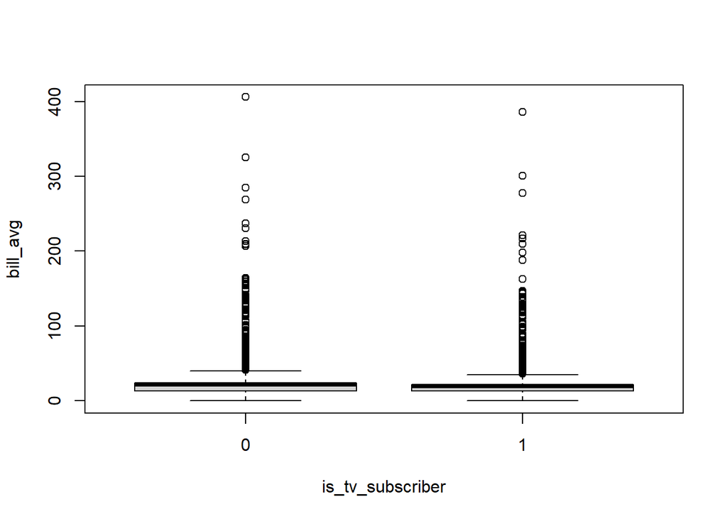

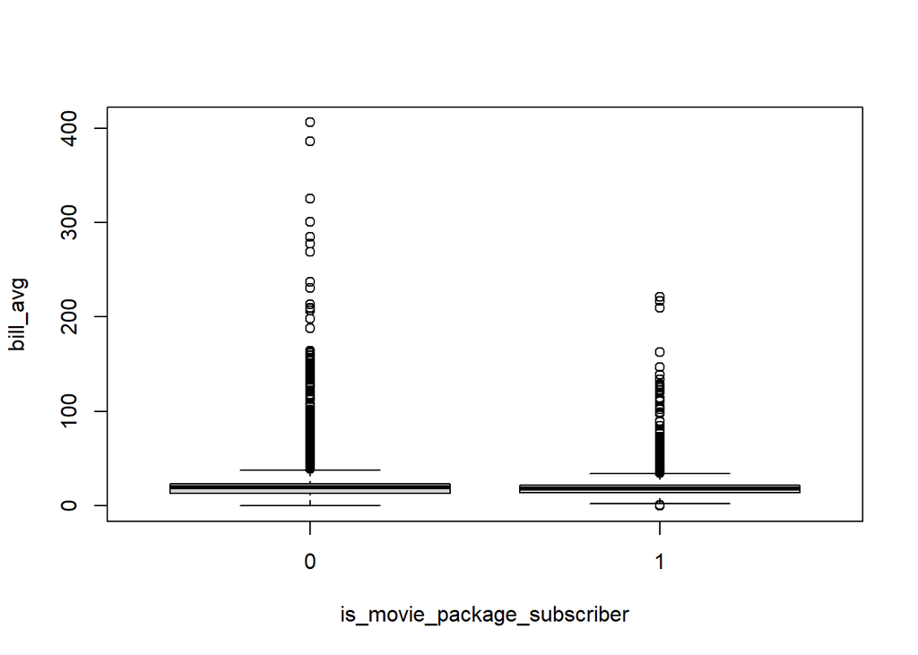

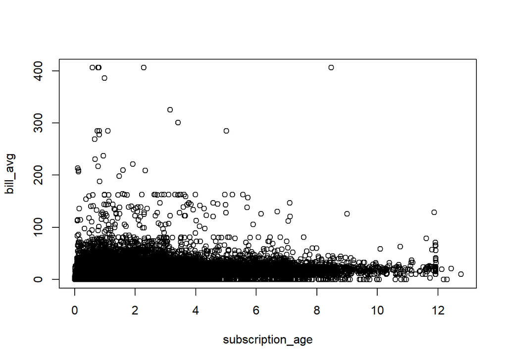

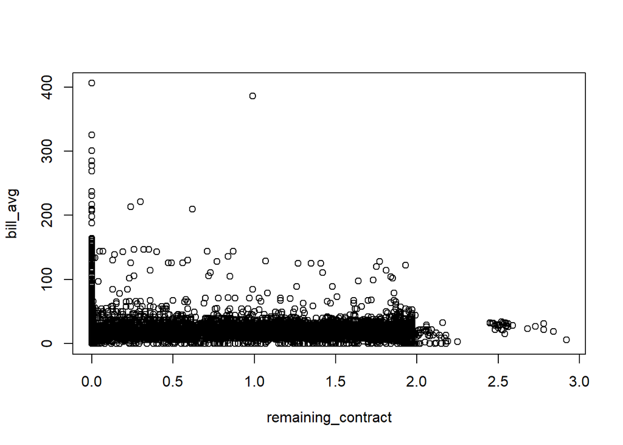

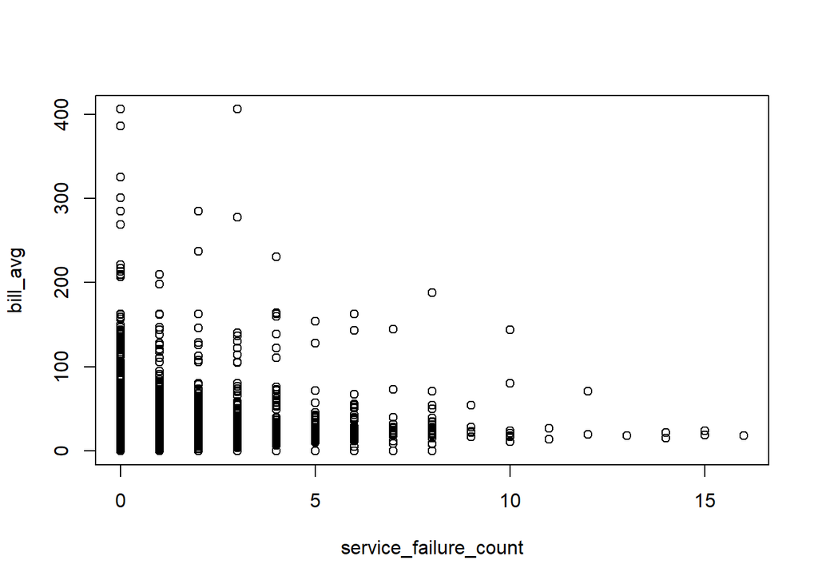

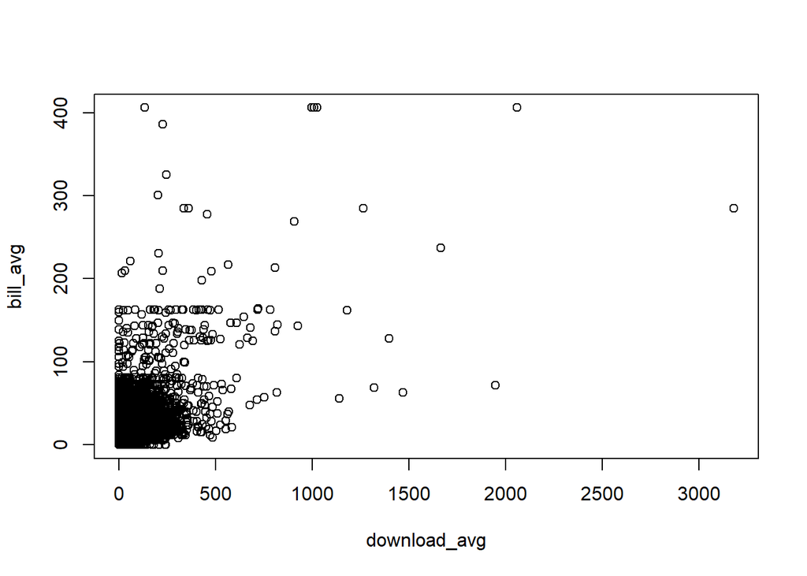

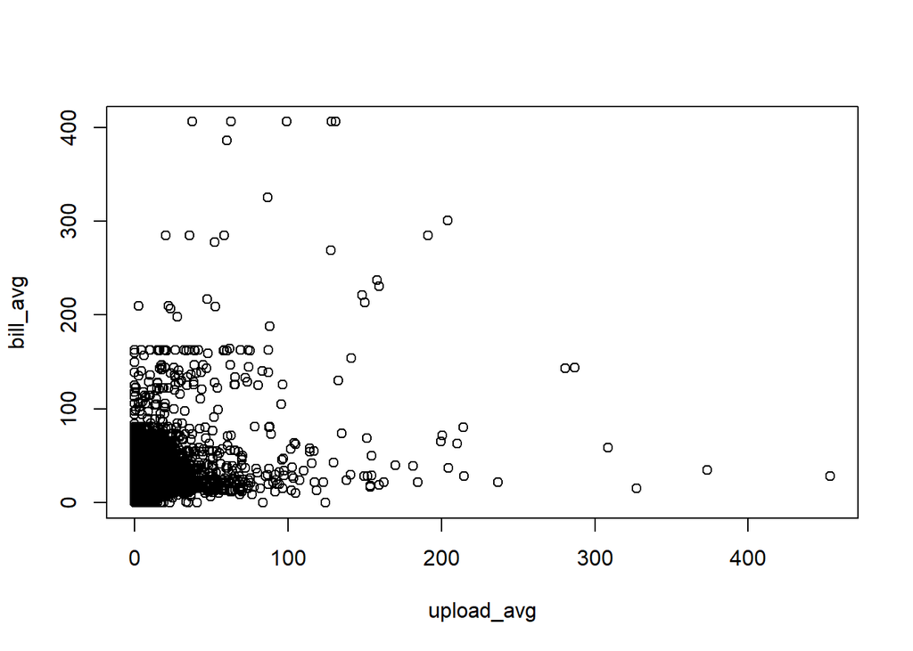

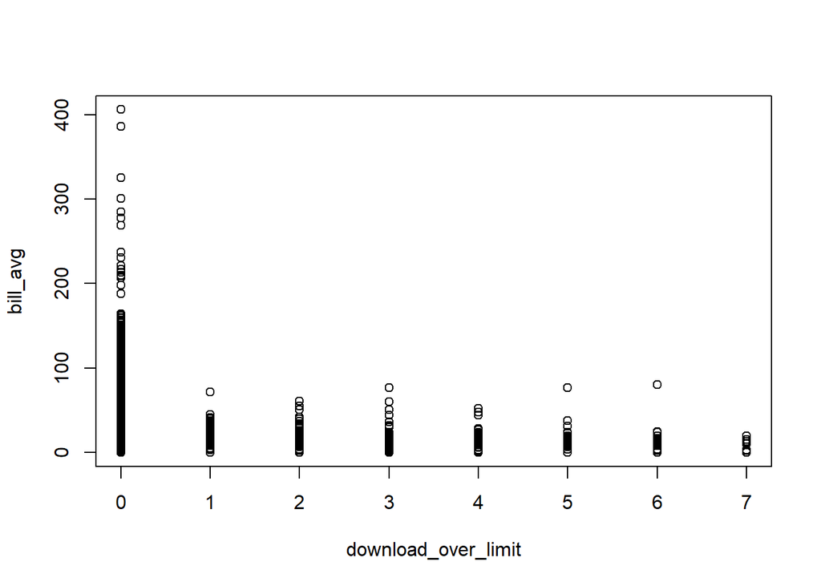

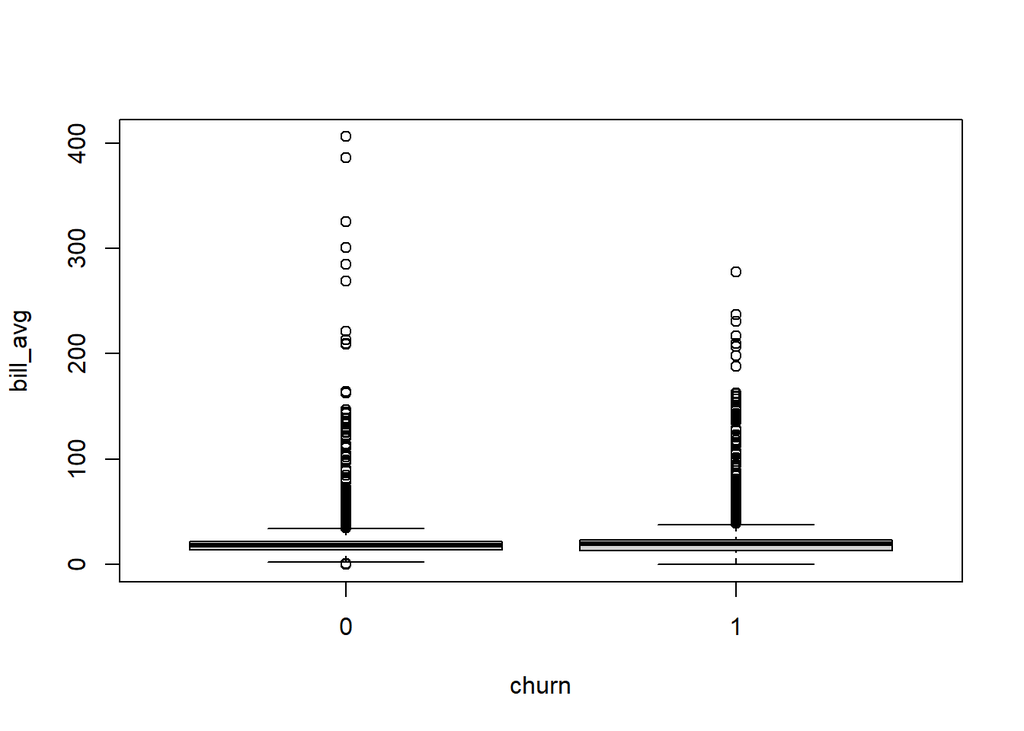

```r
plot(bill_avg ~ ., data = train)
```

The value of bill_avg seems to vary with all predictors, possibly with the exception of download_avg and upload_avg, where patterns are difficult to see visually.

We will now try to produce the best possible predictors of bill_avg using OLS and evauate them.

```r
# Standard linear regression, first with all predictors
lr <- lm(bill_avg ~., data = train)
pred_lr <- predict(lr, newdata = test)
MSE_lr <- mean((test$bill_avg - pred_lr)^2)

# Without download_avg and upload_avg
lr2 <- lm(bill_avg ~. -download_avg -upload_avg, data = train)
pred_lr2 <- predict(lr2,newdata = test)
MSE_lr2 <- mean((test$bill_avg - pred_lr2)^2)

MSE_lr
```

```
## [1] 110.5923
```

```r
MSE_lr2
```

```
## [1] 137.0627
```

MSE is used as a measure since no explicit decision situation was given that could inform what a good prediction would be. Given the conclution from plot analysis above, an experiment was done with removing download_avg and upload_avg. The full model performed much better than the reduced model.

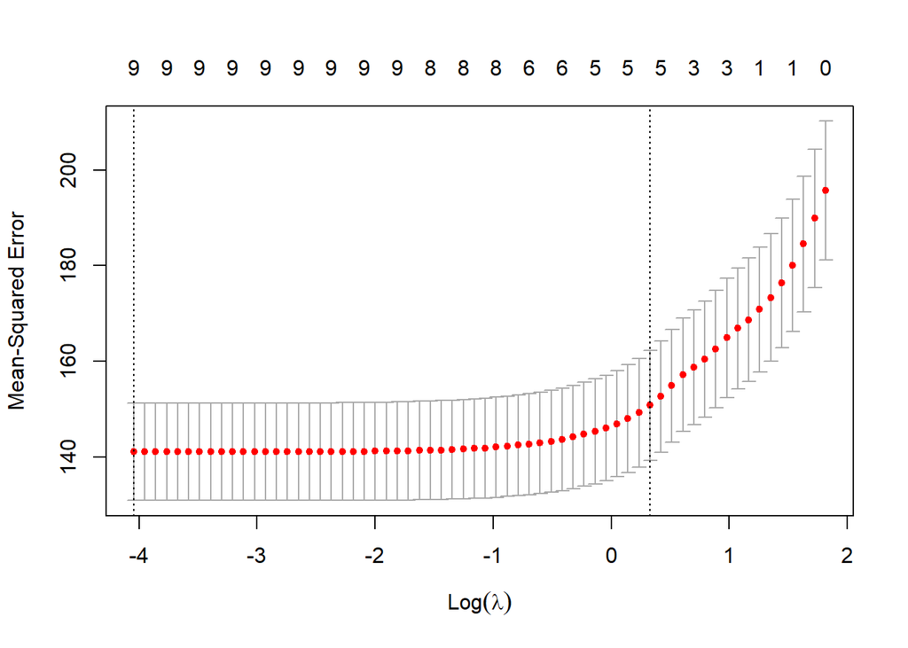

```r
# Test and train half half
set.seed(12454437)

n <- nrow(churn)
ind <- sample(1:n, size = floor(n/2))

train <- churn[ind, ]
test <- churn[-ind, ]
xtest <- model.matrix(bill_avg ~ ., test)[, -1]

# Transform with dummy variables
x <- model.matrix(bill_avg ~ ., train)[, -1]
y <- train$bill_avg

# With cross validation to tune parameters (lambda)
cv_out <- cv.glmnet(x, y, alpha = 1)
plot(cv_out)
```

```r
# Best lambda
best_lam <- cv_out$lambda.min

# LASSO mod
lasso_mod <- glmnet(x, y, alpha = 1, lambda = best_lam)

# Coefficients
lasso_coeff <- predict(lasso_mod, type = 'coefficients', s = best_lam)
lasso_coeff
```

```
## 10 x 1 sparse Matrix of class "dgCMatrix"
##                                       s1
## (Intercept)                  19.11988369
## is_tv_subscriber1            -4.27041037
## is_movie_package_subscriber1 -0.62664817
## subscription_age              0.24880318
## remaining_contract           -2.75579837
## service_failure_count         0.85529574
## download_avg                  0.08735938
## upload_avg                    0.18815847
## download_over_limit          -2.81770493
## churn1                        0.38200677
```

Now I will compute predictions for bill_avg with the model fitted above and evaluate them with testMSE like with OLS before. Which as we can see below, is for all practical purposes, equal to the one for OLS.

```r
# Predictions
lasso_pred <- predict(lasso_mod, s = best_lam, newx = xtest)

# test MSE
mean((test$bill_avg - lasso_pred)^2)
```

```
## [1] 110.5261
```

Now we will try to fit a regression tree to bill_avg.

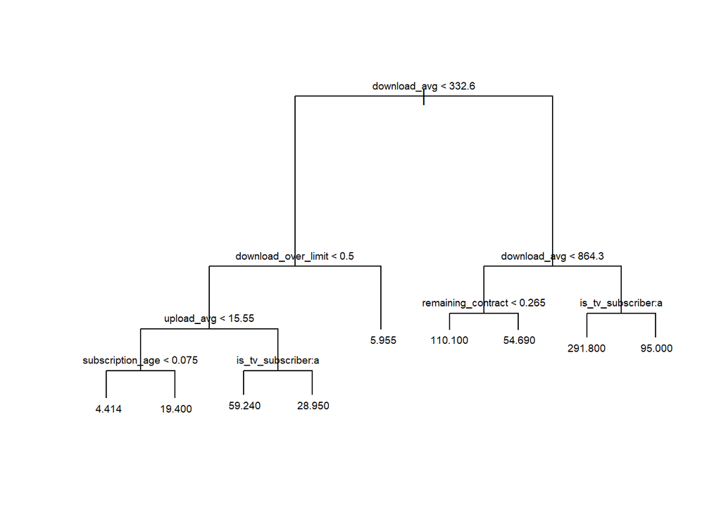

```r
# Tree
tree1 <- tree(bill_avg ~., data = train)

plot(tree1)
text(tree1, cex = 0.6)
```

The lowest average bill, 4.41, is found for customers with a download average of less than 332.6, that have never exceeded the download limit, have an upload average below 15.55 and have been subscribers for less than 0.075 years (almost new customers).

A mechanical interpretation is that the highest average bill, 291.8, is found for customers with a download average above 332.6, who have download average above 864.3 and who are not a TV subscriber. Simplified, the highest average bills are found for non-TV-subscribers with a download average above 864.3.

Now we will use the fitted tree model to predict bill_avg.

```r
# Normal tree
pred_tree <- predict(tree1, newdata = test)

MSEtree <- mean((test$bill_avg - pred_tree)^2)
MSEtree
```

```
## [1] 116.3083
```

A little bit higher MSE might mean that the data have more of linear patterns with predictors and predicted variable. One more explanation is that maybe some predictors do not have a high prediction power, which can lead tree models to overfit the training data by creating too many splits and capturing noise.

We will now try to fit a random forest to bill_avg. We will also make a plot of variable importance measure for the predictors.

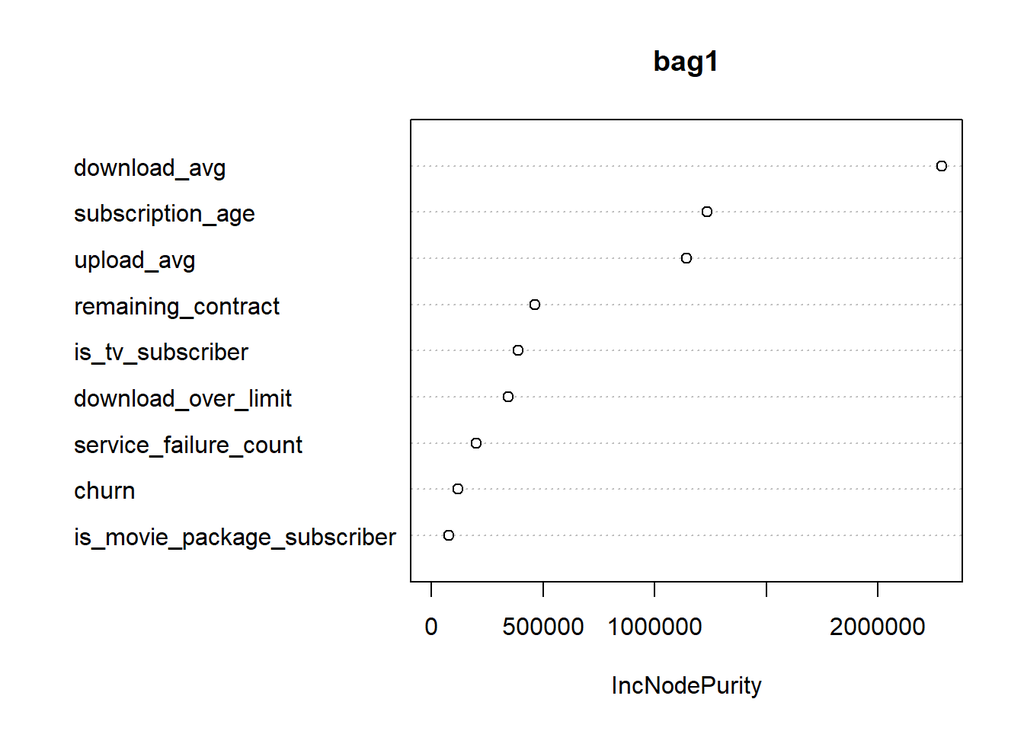

```r
bag1 <- randomForest(bill_avg ~ ., data = train, mtry = 7, ntree = 50)

varImpPlot(bag1)
```

I used 50 trees to reduce computation time. We can see from the VarImpPlot that download_avg has clearly the highest impact on bill_avg, which is not consistent in what we found early on in our exploratory analysis, but it is consistent with the tree model above. We can also see some significant impact from variables like upload_avg and subscription_age.

We will now try to fit our random forest model to predict bill_avg and evaluate the predictions.

```r
pred_forest <- predict(bag1, newdata = test)

MSE <- mean((test$bill_avg - pred_forest)^2)
MSE
```

```
## [1] 101.2005
```

As we can see, the testMSE is significantly lower than other methods we used before.

# Summary

The linear models would imply that a high bill costumer has no TV or movie package subsription, has had subscription for a long time and a short remaining contract, many service failures and high download and upload averages, has not been over the download limit a lot and has churned. A regression tree can gave a more nuanced pattern because of possible non-linearities. In this case, however, the pattern is the same as for the linear model with the exception that all variables does not make it to the tree with the default settings of the tree-function. A customer with a high download average without a TV subscription has a high bill on average. A similar argument can be made for the low bill customers. A natural conclusion from this is that a linear model is appropriate. However, the random forest, a non-linear model, is shown to produce superior predictions, compared to the linear models. If assumptions about the availability of the variables at the time of prediction is made differently in previous, the answer to this question will look somewhat different.